# Overview of 68xx Area Scanner

This lab demonstrates the use of TI mmWave sensors for Area Scanner applications. The range, velocity, and angle data from mmWave sensors can enable the detection of objects or people as they enter or exit zones of interest.

Key features in this lab are the static detection and group tracking algorithms:

- Typically it can be difficult to distinguish static objects of interest that have been left in an area from the static floor or fixtures that are also in the area. Using the static detection algorithm enables the detection of static objects such as boxes, carts, or other equipment that have been left behind while ignoring the permanent static objects that comprise the scene.
- With group tracking, the sensor is able to gauge a moving object’s trajectory and speed, enabling the area scanner system to predict before a safety zone is breached and to dynamically adjust the system’s behavior depending on the object’s speed of approach.

The lab runs on the TI mmWave sensor IWR6843ISK, IWR6843ISK-ODS, or IWR6843AOP (Rev F+) EVM and includes a MATLAB visualizer.

[video not shown]

# Quickstart

The quickstart guide will cover setting up the EVM, flashing firmware, and running the demo.

## Requirements

### Run Out of Box Demo

- Before continuing with this lab, users should first run the out of box demo for the EVM. This will let users gain familiarity with the sensor’s capabilities as well as the various tools used across many of the labs in the Radar Toolbox.

### Required and Supported mmWave Evaluation Modules (EVM)

#### ISK or ODS antenna module with MMWAVEICBOOST

| Quantity | Item |
| --- | --- |
| 1 | Antenna Module Board: IWR6843ISK OR IWR6843ISK-ODS |
| 1 | OPTIONAL: [Industrial mmWave Carrier Board](http://www.ti.com/tool/MMWAVEICBOOST) for CCS based debugging |

OR

#### AOP EVM

| Quantity | Item |
| --- | --- |
| 1 | IWR6843AOPEVM |
| 1 | OPTIONAL: [Industrial mmWave Carrier Board](http://www.ti.com/tool/MMWAVEICBOOST) for CCS based debugging |

## ⚠️ **IWR6843 ES2.0 Only**

This lab is only compatible with ES2.0 version of IWR6843.

### ISK or ODS

If using an IWR6843ISK or IWR6843ISKODS, check the device version on your IWR6843 using the on-chip device markings as shown below

1. If line 4 reads `678A`, you have an ES2 device. In this case, this lab is compatible with your EVM.
2. If line 4 reads `60 GHZi`, you have an older ES1 device. In this case, the lab is NOT compatible with your EVM. ES2 IWR6843ISK/IWR6843ISK-ODS boards are orderable from the EVM link above.

[figure not shown]

### AOP

The IWR6843AoP version of this lab is only compatible with ES2.0 silicon and the corresponding EVM. Please ensure your EVM is the same as in the below image.

[figure not shown]

### Additional Hardware Requirements

| Quantity | Item | Details |
| --- | --- | --- |
| 1 | Computer | Windows 7 or 10 PC |
| 1 | Micro USB Cable |  |
| 1 | Power Supply | If using MMWAVEICBOOST, a 5V, 3A with 2.1-mm barrel jack (center positive). The power supply can be wall adapter style or a battery pack with a USB to barrel jack cable. |

### Software

[output not shown]

## 1. Setup the EVM for Flashing Mode

- **MMWAVEICBOOST + Antenna Module setup:** Follow the instructions for Hardware Setup for Flashing in MMWAVEICBOOST Mode
- **IWR6843ISK or IWR6843ISK-ODS in Standalone/Modular Mode:** Follow the instructions for Hardware Setup of IWR6843ISK/ODS for Flashing Mode
- **AOP in Standalone/Modular Mode:** Follow the instructions for Hardware Setup of IWR6843AOPEVM for Flashing Mode

## 2. Flash the EVM using Uniflash

Flash the binary listed below using UniFlash. Follow the instructions for using UniFlash

| BIN Name | Board |
| --- | --- |
| area_scanner_68xx_demo_isk.bin | IWR6843ISK |
| area_scanner_68xx_demo_ods.bin | IWR6843ISK-ODS |
| area_scanner_68xx_demo_aop.bin | IWR6843AOPEVM |

## 3. Setup the EVM for Functional Mode

- For MMWAVEICBOOST + Antenna Module setup: Follow the instructions for Hardware Setup of MMWAVEICBOOST + Antenna Module for Functional Mode
- For IWR6843ISK or IWR6843ISK-ODS in Standalone/Modular Mode: Follow the instructions for Hardware Setup of IWR6843ISK/ODS for Functional Mode
- For AOP: follow the instructions for Hardware Setup of IWR6843AOPEVM for Functional Mode

At this point, the EVM should be powered, connected to the PC, flashed with the demo, and put in functional mode. The hardware setup is now complete.

## 4. Run the Lab

### 1. EVM Mounting and Scene Conditions

The EVM should be mounted:

- Elevated at least 1m from the ground (mounting height)
- Oriented with the Z-axis towards the ceiling and the Y-axis pointed straight towards the scene of interest. (See EVM images at the top for orientation of axes)
- Tilted in elevation downwards 10 deg (θ = -10)

The static detection algorithm used in this lab records a scene calibration meausurement for the first 15 frames after the CFG file is loaded to the device. This means the scene should be clear of “temporary” objects and people. The recorded calibration scene will be used to determine whether new static obejcts have entered the scene. If the “permanent” background scene changes or the sensor is moved, the calibration will need to be completed again.

### 2. Launch the Visualizer

> ⚠️ *MATLAB Requirement*  
> MATLAB Runtime Version R2019a (9.6) **Exact version** R2019a (9.6) required. Download from: https://www.mathworks.com/products/compiler/matlab-runtime.html Other labs in the Radar Toolbox may use version R2017a (9.2). For this lab, version R2019a (9.6) MUST also be installed.
1. Navigate to `<TOOLBOX_INSTALL_DIR>\tools\visualizers\Area_Scanner_GUI`
2. Double click to launch **area_scanner_visualizer.exe**
3. A black console window will appear. After 30-60sec, a setup window will appear as shown below.

### 3. Configure Visualizer

[figure not shown]

**Visualizer Mode**

1. Click the **Real Time** button
2. In Real Time mode the visualizer will connect to given COM ports and parse the incoming stream for visualization
3. In Play Back mode the visualizer will read in a txt file and enable a user to review the recorded byte stream from a real time session.
4. Enter the COM ports associated with the mmWave EVM.
5. Optional: Use **Test Connection** to ensure that COM ports are available and test command can be sent and received.

**Select CFG File**

1. Use the **Browse** button to select the CFG file to load to the device or enter the full path and file name into the text field box.
2. To load the demo CFG file navigate to `<TOOLBOX_INSTALL_DIR>\source\ti\examples\area_scanner\chirp_configs` and select the **area_scanner_68xx_ISK_demo.cfg** or **area_scanner_68xx_ODS_demo.cfg** file for ISK or ODS boards respectively.

**Record Data**

1. Check the **Enable recording.** option to record the UART stream to a text file for play back later on. Enabling this option will log the byte stream in HEX format to a text file.
2. Specify the **Save Directory** and **File Name** of the log file.

> 📝 **NOTE:** The record data feature will automatically create a text file with the name specified at the save directory. If there is already an existing file with the same name the file will be written over. Ensure path and\or file name are unique if this is not desired.

**Sensor Information**

1. Sensor Mounting Height is the height of the EVM from the floor in meters
2. Sensor Elevation tilt is the angle in degrees the sensor is tilted either upwards towards the ceiling (positive angle) or downwards towards the floor (negative angle)

**Visualizer Options**  
The options in this panel will determine the areas and behavior of the zone occupancy warning. The demo defines two different regions, as well as the projection time, all of which are described below:

- **Critical zone**: In this zone, the presence of any detected objects will trigger the zone to turn red. Use **Range Critical Zone Start** and **Range Critical Zone End** to specify in meters the radial distance from the sensor the region should start and end. By default this is set to 0 to 2m. This means if there’s any detected point cloud or tracked object within 0-2m radially around the sensor - the zone will be triggered.
- **Warning zone**: In this zone, a moving, tracked object will trigger the zone to turn yellow if its current or or projected location is within the zone. Use **Range Warning Zone Start** and **Range Warning Zone End** to specify in meters the radial distance from the sensor the region should start and end. Typically, the critical zone end and warning zone start should be the same value.
- **Projection Time** is used to calculate the projected location of a tracked object. By default this is set at 2 seconds, meaning the object’s location 2 seconds from the current time will be projected from it’s velocity vectors and used in determining whether or not to trigger the warning zone indicator. A longer projection time will result in earlier warnings while a shorter projection time will give less warning time.

**Setup Complete**

- Confirm that the scene is clear of any “temporary” objects.
- When the scene is clear, click the **Setup Complete** button to confirm all the settings and send the config to the mmWave EVM.
- The setup window will close and the main visualizer plot will open next.

> 📝 NOTE: If the mmWave EVM was is currently running, the new config file cannot be resent. The visualizer will instead open and attempt to continue parsing the incoming UART stream. To ensure that the intended CFG file can be loaded, toggle NRST on the EVM before clicking ‘Setup Complete’. (This should have already been done when the EVM was returned to Functional Mode).

### 4. Understanding the Visualizer Output

The window will open in a top-down, X-Y view of the scene.

> 📝 NOTE: The data incoming from the sensor is relative to the sensor itself without consideration for its mounting position. The visualizer transforms and translates the points based on the input sensor information during setup. This is so Z = 0 on the plot correlates with the floor of the scene and the zones are defined on the same plane as the floor.

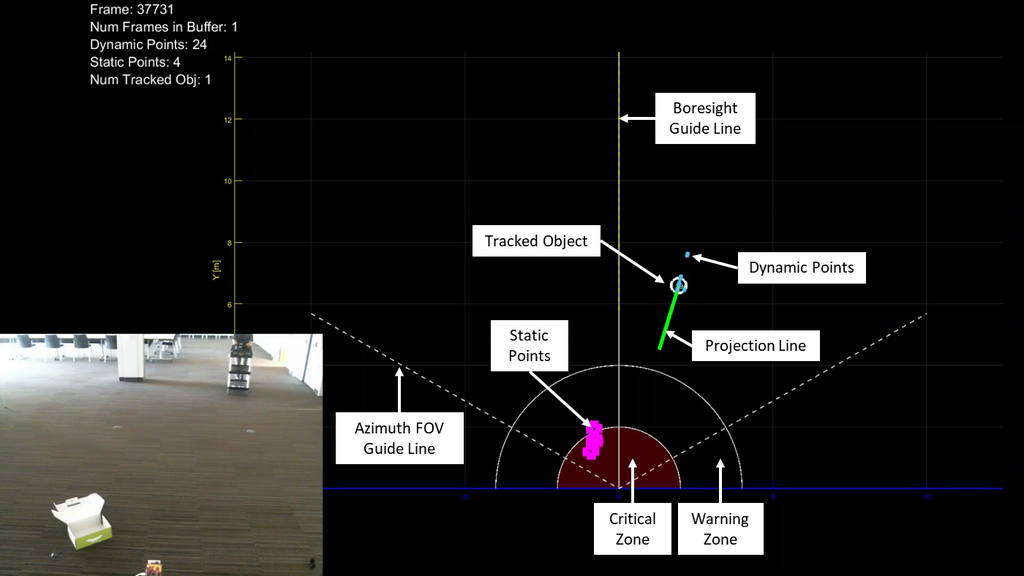

The visualizer will plot three types of detected object data, static point cloud, dynamic point cloud and tracked objects:

**Static Point Cloud**

- The Static Point Cloud is represented by magenta squares and is the output of the static detection processing.
- The point cloud represents newly added static objects to the scene. The primary aim of this detection chain is to detect whether objects such as boxes or carts have been left within the critical zone.
- The presence of static points in the critical zone will trigger the zone.
- Static points outside the critical zone are plotted for visualization purposes but do NOT trigger the warning zone. This is because the warning zone is primarily concerned with objects that can move into the critical zone.

**Dynamic Point Cloud**

- The Dynamic Point Cloud is represented by cyan points and is the output of the traditional range-doppler processing chain (same processing chain as the Out of Box demo from the prerequisite section).
- Since the CFG file has static clutter removal enabled, the point cloud only shows detections for moving objects.

**Tracked Objects**

- Tracked Objects are the output of the GTRACK algorithm and are represented by white circles with a number inside for the tracked object’s ID number. The dynamic point cloud is fed as input to the tracking algorithm which groups and tracks points across the scene.
- Each tracked object will also have a projection line starting from its current position and ending at its projected position. The color of the line represents whether the projected position is in the critical zone (red), warning zone (yellow), or neither (green).
- A longer projection line indicates the tracked object is moving faster while a shorter projection line indicates the tracked object is slower moving.

To end the visualizer session, exit out using the “X” in the upper right corner. If Record Data was enabled this will also close the text file and end recording. The visualizer saves the settings from the setup window and relaunching the visualizer will prepopulate any fields with the same values from the previous session.

### 5. Replay Data

After data has been taken, and if the data was recorded, the Area Scanner visualizer can replay the data again with the following steps:

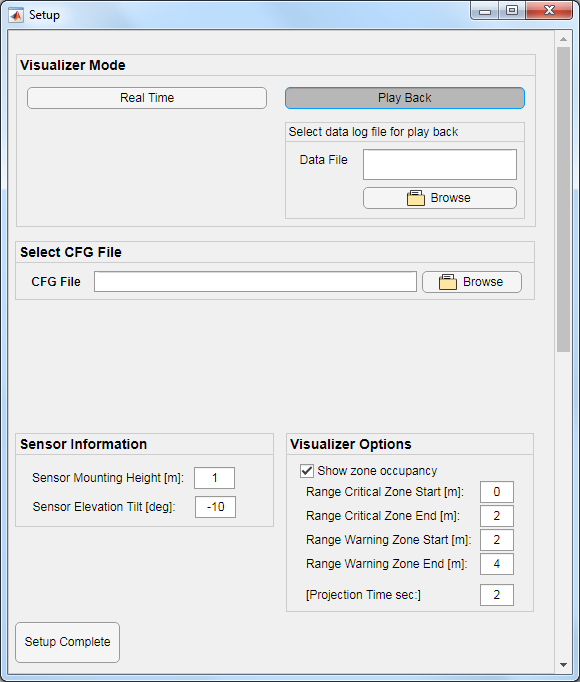

1. Relaunch the visualizer
2. Select **Play Back** mode
3. Browse to and select the the .txt data file to load
4. Browse to and select the CFG file used when the data was collected.
5. Input the Sensor Information parameters. They should match what was used when the data was collected.
6. The Visualizer Options can change for play back if desired.

In addition to plotting the data coming from the mmWave EVM, the visualizer also draws reference lines to indicate the approximate azimuth and elevation field of view (FOV) of the sensor. Using the drop down menu in the left corner, users can switch to other views of the scene. A useful view is the 2D, Y-Z view of the scene which gives an indicator of how the mounting height and down tilt affects the min and max detectable range of the sensor given the narrower elevation FOV. The image below is from using the visualizer in play back mode to examine the Y-Z view. The view shows how the lower elevation FOV guideline intersects with the ground, marking the boundary for minimum detectable range. Outside the guide lines, the antenna gain is below a threshold at which detection of objects can be difficult. When debugging missed detections it’s important to consider the effect of sensor placement and mounting.

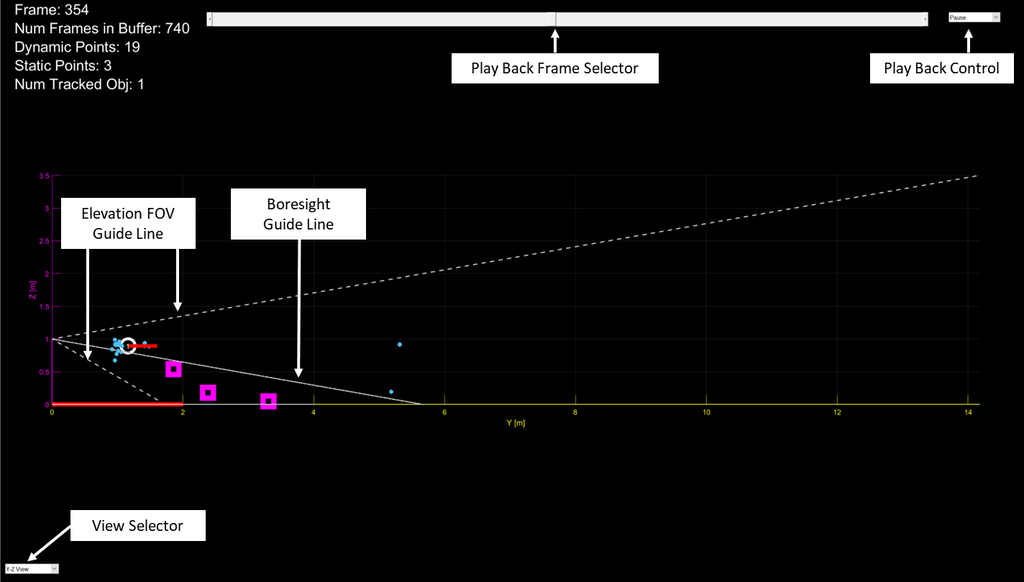

This concludes the Quickstart Section.

# Developer’s Guide

## Build the Firmware from Source Code

### 1. Software Requirements

[output not shown]

### 2. Import Lab Project

To import the source code into your CCS workspace, CCS projects are provided for the mmWave SDK Out-of-box demo in the Radar Toolbox.

⚠️ **Project Workspace**  
When importing projects to a workspace, the files are LINKED into the workspace. It is important to note that modifying the files in the CCS workspace will also affect the source files. Practice version control in the case that revisions need to be reverted.

- Start CCS and setup workspace as desired.
- Import the project(s) specified below to CCS. See instructions for importing here

| Project Name | Location in Toolbox |
| --- | --- |
| area_scanner_68xx_dss | Do not import. Automatically imported with mss project. |
| area_scanner_68xx_mss | `<TOOLBOX_INSTALL_DIR>\source\ti\examples\area_scanner\src` |

- Verify that the import occurred without error: in CCS Project Explorer both **area_scanner_68xx_dss** and **area_scanner_68xx_mss** projects should appear.

> 📝 **NOTE**  
> If an error occurs during the import into IDE, check that the software dependencies listed above have been installed. Errors will occur if necessary files are not installed in the correct location for importing.

### 3. Build the Lab

> 📝 **NOTE**  
> The same lab projectspec is provided to support either the ISK, ODS, or AOP evm. Users can control which EVM to build for by setting the Active Build Configuration as shown below.
1. Select the **area_scanner_68xx_mss** so it is highlighted. Right click on the project and select **Build Configurations** –> **Set Active** –> **isk** or **ods** or **aop** based on the EVM
2. Select the **area_scanner_68xx_dss** so it is highlighted. Right click on the project and select **Build Configurations** –> **Set Active** –> **isk** or **ods** or **aop** based on the EVM
3. Select the **area_scanner_68xx_mss** so it is highlighted. Right click on the project and select **Rebuild Project**. The DSS project will automatically build first and then the MSS project.
4. On successful build, the following should appear:
- **ISK:**
  - In area_scanner_68xx_dss\isk, **area_scanner_68xx_dss_isk.xe674** (this is the C67x binary used for CCS debug mode)
  - In area_scanner_68xx_mss\isk, **area_scanner_68xx_mss_isk.xer4f** (this is the Cortex R4F binary used for CCS debug mode) and **area_scanner_68xx_demo_isk.bin** (this is the flashable binary used for deployment mode)
- **ODS:**
  - In area_scanner_68xx_dss\ods, **area_scanner_68xx_dss_ods.xe674** (this is the C67x binary used for CCS debug mode)
  - In area_scanner_68xx_mss\ods, **area_scanner_68xx_mss_ods.xer4f** (this is the Cortex R4F binary used for CCS debug mode) and **area_scanner_68xx_demo_ods.bin** (this is the flashable binary used for deployment mode)
- **AOP:**
  - In area_scanner_68xx_dss\aop, **area_scanner_68xx_dss_aop.xe674** (this is the C67x binary used for CCS debug mode)
  - In area_scanner_68xx_mss\aop, **area_scanner_68xx_mss_aop.xer4f** (this is the Cortex R4F binary used for CCS debug mode) and **area_scanner_68xx_demo_aop.bin** (this is the flashable binary used for deployment mode)

> 📝 **NOTE**  
> Please set same Active Build Configuration for both MSS and DSS project.

> 📝 **NOTE**  
> Selecting Rebuild instead of Build ensures that the project is always re-compiled. This is especially important in case the previous build failed with errors.

> 📝 **NOTE**  
> If the build fails with errors, please ensure that all the software requirements are installed as listed above and in the mmWave SDK release notes.

> 📝 **NOTE**  
> As mentioned in the Quickstart section, pre-built binary files, both debug and deployment binaries are provided in the pre-compiled directory of the lab.

### 4. Execute the Compiled Lab

There are two ways to execute the compiled code on the EVM: **Deployment mode**: In Deployment mode, the EVM boots autonomously from flash and starts running the bin image * Use the **area_scanner_68xx_demo.bin** found at `<CCS_PROJECT_WORKSPACE_DIR>\area_scanner_68xx_mss\[Build-Folder]\` and follow the same process in the Quickstart section except flash this binary instead.

- **Debug mode**: This mode is is used for downloading and running the executable from CCS. This mode enables JTAG connection with CCS while the lab is running and is useful during development and debugging.
  - Follow the CCS Debug Mode Guide, using the binaries listed below where EVM type correlates to the selected build configuration .
- After CCS Debug mode is setup, launch the visualizer and proceed as described in the Run the Lab section of the Quickstart

| Debug binary | Location | Connect and load to |
| --- | --- | --- |
| area_scanner_68xx_dss_evm type.xe674 | `<CCS_PROJECT_WORKSPACE_DIR>\area_scanner_68xx_dss\<EVM-TYPE>\` | C674X_0 |
| area_scanner_68xx_mss_evm type.xer4f | `<CCS_PROJECT_WORKSPACE_DIR>\area_scanner_68xx_mss\<EVM-TYPE>\` | Cortex_R4_0 |

### 5. Work with GUI source code

> 📝 **NOTE**  
> Working with and running the visualizer source files requires a full MATLAB license not just the MATLAB Runtime Engine
- The visualizer source files are located at `<TOOLBOX_INSTALL_DIR>\tools\visualizers\Area_Scanner_GUI`
- Running area_scanner_visualizer.m results in the same fucntionality as the executable used inthe Quick Start section; please refer to the section for details.

Files of interest:

- area_scanner_visualizer.m: Main visualizer script that calls the setup, parsing, and plotting functions.
- readUARTToBuffer.m: Copies any bytes available on the serial port object to a buffer in the Matlab workspace
- parseBytes: Receives the buffer and parses bytes into an output struct representing the data in the frame.

## Data Output Format

Output packets with the detection information are sent out every frame through the UART. Each packet consists of a Frame Header as shown below and a possibly variable number of TLV items containing various demo information. Each TLV item consists of type, length, and payload information. Since the length of the packet depends on the number of dynamic points, static points, and tracked objects it can vary from frame to frame. The end of the packet is padded so that the total packet length is always multiple of 32 Bytes.

### Headers

#### Frame Header

**Length:** 44 Bytes  
A Frame Header is sent at the start of each packet. Use the Magic Word to find the start of each packet.

| Value | Type | Bytes |
| --- | --- | --- |
| Magic Word | uint16_t | 8 |
| Version | unint32_t | 4 |
| Total Packet Length | unint32_t | 4 |
| Platform | unint32_t | 4 |
| Frame Number | unint32_t | 4 |
| Time [in CPU Cycles] | unint32_t | 4 |
| Num Detected Obj | unint32_t | 4 |
| Num TLVs | unint32_t | 4 |
| Subframe Number | unint32_t | 4 |
| Num Static Detected Obj | unint32_t | 4 |

#### TLV Header

**Length:** 8 Bytes  
A TLV Header is sent at the start of each TLV.

| Value | Type | Bytes |
| --- | --- | --- |
| Type | unint32_t | 4 |
| Length [number of bytes] | unint32_t | 4 |

### Type Length Values (TLVs)

The number of TLVs in a given packet is extracted from the Frame Header. For each TLV, there is a TLV Header containing Type and Length information. The Length value gives the length of the payload. The payload should be parsed according to the appropriate Type identifier as listed in the tables below:

#### **Detected Object (Dynamic Points)**

**Type:** 1  
**Length:** 16 Bytes x Num Detected Obj  
The payload consists of 16 bytes representating position and doppler of EACH point in the dynamic point cloud.

> 📝 **NOTE**: each point’s position is given in spherical coordinates.

| Value | Type | Bytes |
| --- | --- | --- |
| range [m] | float | 4 |
| angle [rad] | float | 4 |
| elev [rad] | float | 4 |
| doppler [m/s] | float | 4 |

#### **Detected Object (Dynamic Points) Side Info**

**Type:** 7  
**Length:** 4 Bytes x Num Detected Obj The payload consists of 4 bytes for EACH point in the dynamic point cloud. The values for snr and noise are determined as described in the doxygen documentation for the mmWave SDK Demo.

| Value | Type | Bytes |
| --- | --- | --- |
| snr | uint16_t | 2 |
| noise | uint16_t | 2 |

#### **Static Detected Object (Static Points)**

**Type:** 8  
**Length:** 16 Bytes x Num Static Detected Obj  
The payload consists of 16 bytes representating position and doppler of EACH point in the static point cloud.

> 📝 **NOTE**: each point’s position is given in cartesian coordinates.

| Value | Type | Bytes |
| --- | --- | --- |
| x [m] | float | 4 |
| y [m] | float | 4 |
| z [m] | float | 4 |
| doppler [m/s] | float | 4 |

#### **Static Detected Object (Static Points) Side Info**

**Type:** 9  
**Length:** 4 Bytes x Num Detected Obj The payload consists of 4 bytes for EACH point in the static point cloud. The values for snr and noise are determined as described in the doxygen documentation for the mmWave SDK Demo.

| Value | Type | Bytes |
| --- | --- | --- |
| snr | uint16_t | 2 |
| noise | uint16_t | 2 |

#### **Tracked Object List**

**Type:** 10  
**Length:** 40 Bytes x Num Tracked Objects  
The payload consists of 40 bytes for EACH tracked object, giving the ID, position, velocity, and acceleration components of each target.

| Value | Type | Bytes |
| --- | --- | --- |
| Target ID | uint32_t | 4 |
| pos X [m] | float | 4 |
| pos Y [m] | float | 4 |
| vel X [m/s] | float | 4 |
| vel Y [m/s] | float | 4 |
| acc X [m/s^2] | float | 4 |
| acc Y [m/s^2] | float | 4 |
| pos Z [m] | float | 4 |
| vel Z [m/s] | float | 4 |
| acc Z [m/s^2] | float | 4 |

#### **Point to Track Association**

**Type:** 11  
**Length:** 1 Byte x Num Detected Obj  
The payload consists of 1 byte for EACH point in the dynamic point cloud. If point *n* was associated to a target, the value of Target ID will be the ID of the associated Target. Otherwise, the value will indicated the reason the point was not associated.

| Value | Type | Bytes |
| --- | --- | --- |
| Target ID | uint8_t | 1 |

where Target ID can have the following values:

| Value | Meaning |
| --- | --- |
| <250 | The ID of the tracked object the point has been associated to |
| 253 | Point not associated, doesn’t meet SNR requirements |
| 254 | Point not associated, located outside Boundary Box area |
| 255 | Point not associated, considered noise |

# Optimizing for FCC Restrictions (USA Only)

TI provides additional .cfg files that reduce the output power or bandwidth of the chirp so users can anticipate these restrictions and develop a product that works effectively within the FCC’s constraints. These files are called area_scanner_68xx_AOP_full_power_low_bandwidth.cfg and area_scanner_68xx_AOP_low_power_full_bandwidth.cfg.

TI recommends using range resolution and maximum range requirements to inform which .cfg file to use. Selecting the Low Power / Full Bandwidth .cfg file increases resolution at the cost of reduced maximum range, and selecting the Full Power / Low Bandwidth option increases maximum range at the cost of reduced resolution. See the flowchart below for more details.

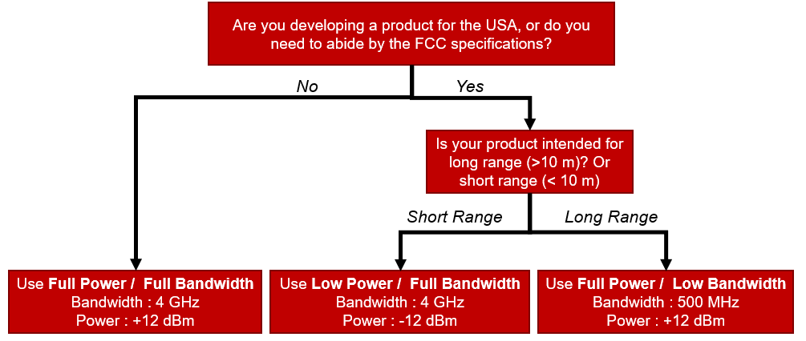

The main difference in these files is the profileCfg line, which sets the Bandwidth and txOutPowerBackoff values for the chirp. For a full description of each of the values in this line, consult the SDK User’s Guide, found in the [mmWave SDK](https://www.ti.com/tool/MMWAVE-SDK) installation directory under `<mmwave sdk>\docs`

| Configuration | Full Power / Full Bandwidth | Low Power / Full Bandwidth | Full Power / Low Bandwidth |
| --- | --- | --- | --- |
| ProfileCfg | `profileCfg 0 60 100 10 79` `0 0 50 1 256 4000 0 0 30` | `profileCfg 0 60 100 10 79` `1579032 0 50 1 256 4000 0 0 30` | `profileCfg 0 61 100 2 69` `0 0 7 1 256 4000 0 0 30` |
| Bandwidth | 3.95 GHz | 3.95 GHz | 480 MHz |
| Power | +12 dBm | -12 dBm | +12 dBm |
| Range Resolution | 0.047 m | 0.047 m | 0.33 m |
| Maximum Range | 10.8 m | 10.8 m | 77 m |

> 📝 **NOTE**  
> Bandwidth is calculated by multiplying the frequency slope (8th value in ProfileCfg line) by the Ramp End Time (5th value in ProfileCfg line). Power is calculated by subtracting the TX Power Backoff Value (6th value in ProfileCfg line) ) from the maximum value of 12.

> 📝 **NOTE**  
> The TX Power Backoff Value (6th value in ProfileCfg line) is formatted as the three TX Power Backoff values (one for each transmitter) all together in hexidecimal. For example, the low power value of 1579032 can be decoded by converting it to hex, separating out the three pairs of bytes that correspond to TX0, TX1 and TX2, and subtracting them from the maximum value of +12 to get the TX Power of -12 dBm. Users can therefore vary the TX Power for each transmitter if they choose.

1579032<sub>10</sub> = 0x181818. 0x18 = 24<sub>10</sub> dB.

12 dBm - 24 dB = -12 dBm.

# Need More Help?

- Additional resources in the documentation of the mmWave SDK:
  - mmWave SDK Module Doc located at `<mmwave_sdk_install_dir>/docs/mmwave_sdk_module_documentation.html`
  - mmWave SDK User’s Guide located at `<mmwave_sdk_install_dir>/docs/mmwave_sdk_user_guide.pdf`
- Search for your issue or post a new question on the [mmWave E2E forum](https://e2e.ti.com/support/sensor/mmwave_sensors/f/1023)